# Seaborn

除了坐标变量和数据，还有几个通用的变量

1. 语义变量

hue：根据该类别分类，绘制不同的颜色

style：根据该类别分类，绘制不同的标记样式。

**如果同时有这两个参数，则会进行组合，比如hue有2种，style也有两种，则总共会有四种组合**

size：根据类别为某些点绘制大小，会自动为数值型变量分簇

相关设置参数：

hue_order:

style_order:

1. 方面变量

row：根据row变量的种类进行行排列

col：根据col变量的种类进行列排列

row，和col同时用时，则首先就会有者两种变量形成多个轴域，然后分别在这些轴域中分别绘制相应数据范围的图形。

相关设置参数：

row_order=顺序列表

col_order=顺序列表

col和col_wrap搭配：col_wrap=3指定仅绘制三列，然后将其包装到下一行。使用此选项时，不能使用row参数。

没有row_wrap参数

1. data

可以放入data，也可以利用`data.query("条件")`筛选某些行，注意要打双引号.

1. height，aspect

height指定画布的高(英寸)，aspect指定宽比上高的倍数，比如height=6，aspect=2代表高6英寸，宽12英寸。

1. palette参数

调色板，可以用系统给的取值，比如Set1,Set2,muted,husl.也可以用cmap参数，同时也可以自定义，用字典形式为hue的分类定义颜色，为分类变量的分类值定义颜色。

1. sns.despine()函数

使轴域的上轴线和右轴线不可见。 如果要使左轴和底轴也不可见，则可以传递参数left=True和right=True。

当使用通用函数时，不能使用plt的多图

```python
import matplotlib.pyplot as plt
import seaborn as sns
```

```python
import pandas as pd
import numpy as np
```

```python
data=pd.read_csv(r'C:\Users\WangChengLong\Desktop\python\data\mtcars.csv')
data.head(5)
```

|  | name | mpg | cyl | disp | hp | drat | wt | qsec | vs | am | gear | carb |
| --- | --- | --- | --- | --- | --- | --- | --- | --- | --- | --- | --- | --- |
| 0 | Mazda RX4 | 21.0 | 6 | 160.0 | 110 | 3.90 | 2.620 | 16.46 | 0 | 1 | 4 | 4 |
| 1 | Mazda RX4 Wag | 21.0 | 6 | 160.0 | 110 | 3.90 | 2.875 | 17.02 | 0 | 1 | 4 | 4 |
| 2 | Datsun 710 | 22.8 | 4 | 108.0 | 93 | 3.85 | 2.320 | 18.61 | 1 | 1 | 4 | 1 |
| 3 | Hornet 4 Drive | 21.4 | 6 | 258.0 | 110 | 3.08 | 3.215 | 19.44 | 1 | 0 | 3 | 1 |
| 4 | Hornet Sportabout | 18.7 | 8 | 360.0 | 175 | 3.15 | 3.440 | 17.02 | 0 | 0 | 3 | 2 |

```python
sns.set(style='darkgrid')
```

# 绘制关系图

关系图是一个连续变量和另一个连续变量之间的关系。主要有lineplot和scatterplot。也可以通用relplot，利用kind参数设置line或scatter,我们以relplot介绍。他默认的种类(kind参数)是scatter.

通过设置dashes=False，可以让虚线线条失效。变成实线，默认是True。设置为False后可能style的线条样式虚线和实线都会变成实线 对于线性关系图，通过设置markers=True,可以设置style时，让点的样式显现出来。或者是通过markers=[自己定义的样式列表]

## 绘制一对一的线性关系图

一对一的关系图是一个值对应另一个值，比如一天对应一个数据。像是：

| x1 | x2 |
| --- | --- |
| 1 | 2 |
| 3 | 4 |
| 5 | 6 |
| 7 | 8 |

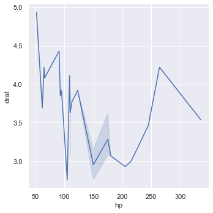

```python
sns.relplot('hp','drat',data=data,kind='line')
```

## 绘制一对多的线性关系图

一对多的线性关系图代表可能一个值对应了多个值

比如虽然一天对应一个数据，但是现在我以月份作为划分，那我一个月就对应了30个数据，此时数据会已平均值绘制线，并且默认显示置信区间。

数据比如：

| x1 | x2 |
| --- | --- |
| 1 | 10 |
| 2 | 11 |
| 1 | 12 |
| 2 | 13 |

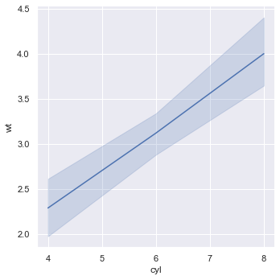

```python
sns.relplot('cyl','wt',data=data,kind='line')
```

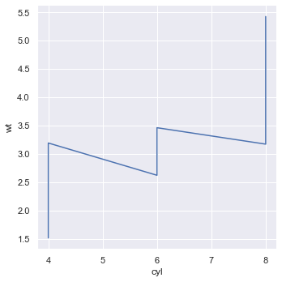

```python
sns.relplot('cyl','wt',data=data,kind='line',estimator=None)
```

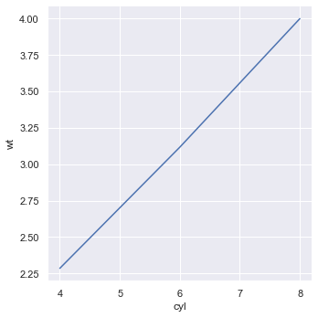

```python
sns.relplot('cyl','wt',data=data,kind='line',ci=None)
```

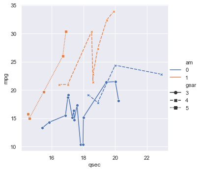

```python
sns.relplot('qsec','mpg',data=data,kind='line',markers=True,ci=None,hue='am',style='gear')
```

它使用默认参数ci=95，这意味着要计算每个平均点周围的 95% 置信区间，并绘制每个平均点周围的范围，将所有这些平均点连接为线形图，最后对这些平均点之间的范围区域进行着色

您还可以通过指定estimator=None作为参数来关闭平均值和置信区间。 由于变量具有一对多关系，因此该图采用锯齿形！

使用ci参数设置置信区间，既可以是数字，代表百分比，也可以是方差，标准差('sd')等,代表数据的一些统计量

使用ci=None关闭置信区间，但是仍然以平均值来绘制图形

通过指定err_style='bars'和 68% 的置信区间ci=68，我们将默认线形图更改为误差图,此时置信区间区域被bars代替

```python
data.head(5)
```

|  | name | mpg | cyl | disp | hp | drat | wt | qsec | vs | am | gear | carb |
| --- | --- | --- | --- | --- | --- | --- | --- | --- | --- | --- | --- | --- |
| 0 | Mazda RX4 | 21.0 | 6 | 160.0 | 110 | 3.90 | 2.620 | 16.46 | 0 | 1 | 4 | 4 |
| 1 | Mazda RX4 Wag | 21.0 | 6 | 160.0 | 110 | 3.90 | 2.875 | 17.02 | 0 | 1 | 4 | 4 |
| 2 | Datsun 710 | 22.8 | 4 | 108.0 | 93 | 3.85 | 2.320 | 18.61 | 1 | 1 | 4 | 1 |
| 3 | Hornet 4 Drive | 21.4 | 6 | 258.0 | 110 | 3.08 | 3.215 | 19.44 | 1 | 0 | 3 | 1 |
| 4 | Hornet Sportabout | 18.7 | 8 | 360.0 | 175 | 3.15 | 3.440 | 17.02 | 0 | 0 | 3 | 2 |

展示一下col和row的用法

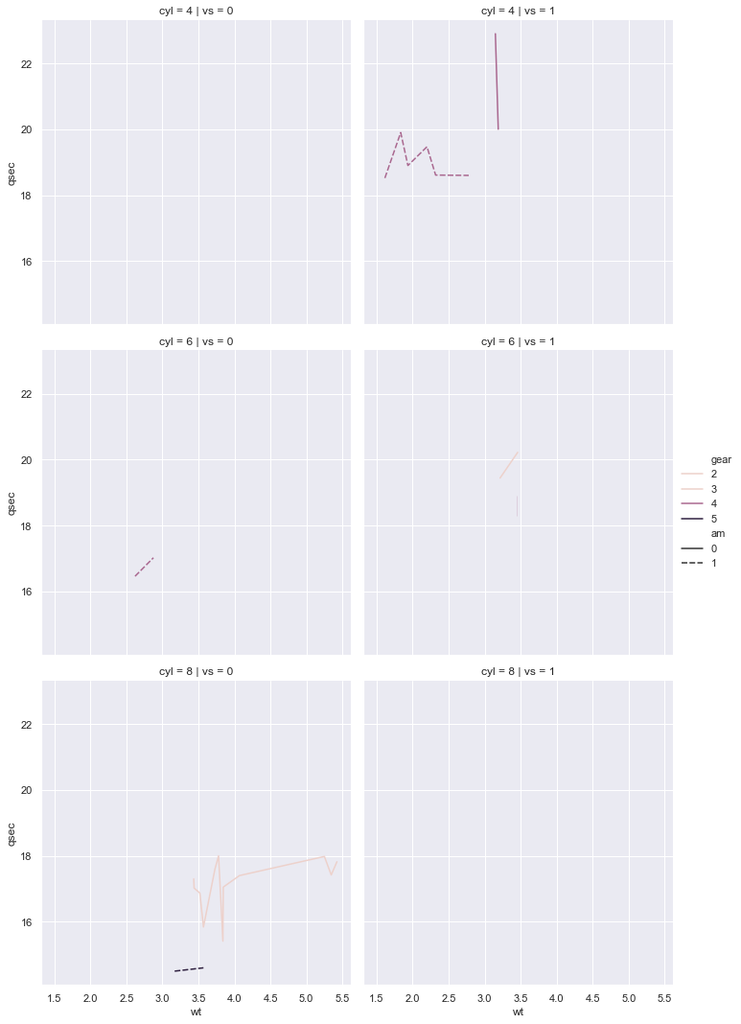

```python
sns.relplot('wt','qsec',data=data,row='cyl',col='vs',hue='gear',style='am',kind='line')
```

## 绘制散点图

其实绘制散点图，就是把kind设置成scatter，没有太大差别。然后散点图可以直接设置markers的自定义样式，可以直接设置点的大小。

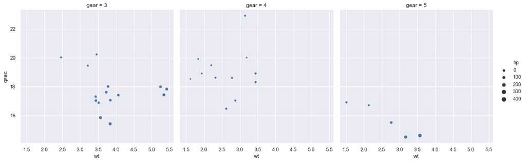

```python
sns.relplot('wt','qsec',data=data,col='gear',col_wrap=3,size='hp')
```

# 类别图

通用函数为sns.catplot()，kind参数为

条带图|群体图|提琴图|箱线图|更多分位数的箱线图|条形图|点图|数量图 strip|swarm|violin|box|boxen|bar|point|count

也可以单独绘制，比如strip就是stripplot，其他参数也是这样。

order参数，为其中的分类变量设置顺序。

## stripplot条带图

条带图是在每一个分类上绘制点，并且会对点在该类别的直线上进行一定的分离，否则每一个类都是一条直线。有重叠，有分离。

参数:

`jilter`:jitter=0.05指定要应用的抖动量；值越大，偏离直线范围越大。jitter的默认值固定值，而是根据输入数据分布而变化。我们还可以通过指定jitter=False来关闭抖动，在这种情况下，其输出将类似于 Matplotlib 的输出。

`dodge`:如果要并排绘制`hue`变量值，而不是在同一条带上同时显示两种颜色，则可以传递和dodge=True参数。 对于stripplot()，默认为dodge=False，这是我们在此处使用的内容。

`palette`:palette='Set1'指定要应用的调色板。 它类似于 Matplotlib 的cmap。 我们也可以在此处使用 Matplotlib 提供的cmap选项。它设置每个类别的颜色。

```python
data.columns
```

```
Index(['name', 'mpg', 'cyl', 'disp', 'hp', 'drat', 'wt', 'qsec', 'vs', 'am',
       'gear', 'carb'],
      dtype='object')
```

[figure not shown]

[figure not shown]

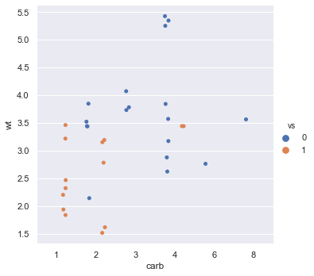

```python
fig=plt.figure()
plt.subplot(1,2,1)
sns.catplot('carb','wt',kind='strip',hue='vs',data=data)
plt.subplot(1,2,2)
sns.catplot('carb','wt',kind='strip',data=data,hue='vs',dodge=True)
```

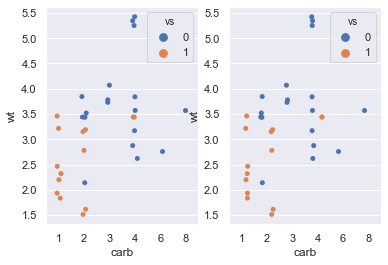

```python
fig=plt.figure()
plt.subplot(1,2,1)
sns.stripplot('carb','wt',hue='vs',data=data)
plt.subplot(1,2,2)
sns.stripplot('carb','wt',data=data,hue='vs',dodge=True)
```

可以看到catplot不支持matplotlib.pyploy的多图设置。但是单独绘制其中的种类是适用的。

## 群体图swarmplot

群体图和条带图差不多，只不过他的算法让点之间不会有一点重复。 ddoge,Palette参数

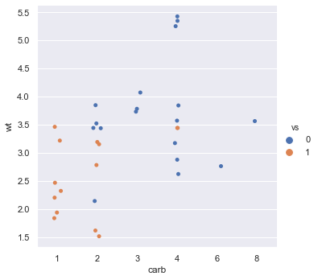

```python
sns.catplot('carb','wt',data=data,hue='vs')
```

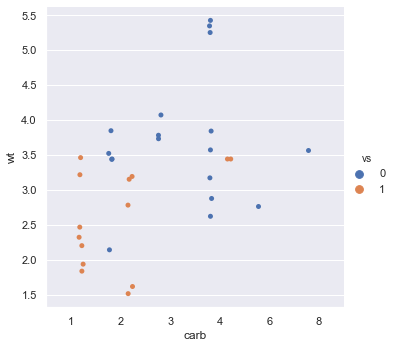

```python
sns.catplot('carb','wt',data=data,hue='vs',dodge=True)
```

## 箱形图（box）和 Boxn 图（boxen）

boxplot()与我们在 Matplotlib 中看到的类似，boxenplot()是 Seaborn 的扩展，旨在提供有关该关系的更多详细信息。

boxplot()提供中值（框内的线），第一个（框的底部）和第三个四分位数（框的顶部），顶部和底部的 1.5 IQR（1.5 倍的框的大小（垂直图的高度，水平图的宽度））位置的胡须，以及胡须以外的异常值的详细信息。 几百个观察说，对于大多数情况来说和数据集的大小很小，这已经足够了。

但是，当数据集很大时，则无法对和尾端提供足够的见解。boxnplot()通过提供多个四分位数覆盖两端的尾端来解决boxplot()的这一局限性。

dodge=True是boxplot()和boxnplot()的默认值，因此默认情况下，将为和色调变量的每个唯一值绘制一个单独的图。 如果要在同一个箱图上绘制两个图，则必须传递dodge=False参数。

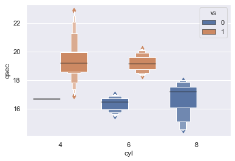

```python
sns.boxenplot('cyl','qsec',data=data,hue='vs')
```

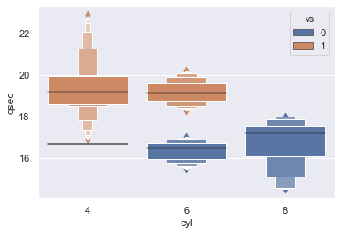

```python
sns.boxenplot('cyl','qsec',data=data,hue='vs',dodge=False)
```

```python
data.head(5)
```

|  | name | mpg | cyl | disp | hp | drat | wt | qsec | vs | am | gear | carb |
| --- | --- | --- | --- | --- | --- | --- | --- | --- | --- | --- | --- | --- |
| 0 | Mazda RX4 | 21.0 | 6 | 160.0 | 110 | 3.90 | 2.620 | 16.46 | 0 | 1 | 4 | 4 |
| 1 | Mazda RX4 Wag | 21.0 | 6 | 160.0 | 110 | 3.90 | 2.875 | 17.02 | 0 | 1 | 4 | 4 |
| 2 | Datsun 710 | 22.8 | 4 | 108.0 | 93 | 3.85 | 2.320 | 18.61 | 1 | 1 | 4 | 1 |
| 3 | Hornet 4 Drive | 21.4 | 6 | 258.0 | 110 | 3.08 | 3.215 | 19.44 | 1 | 0 | 3 | 1 |
| 4 | Hornet Sportabout | 18.7 | 8 | 360.0 | 175 | 3.15 | 3.440 | 17.02 | 0 | 0 | 3 | 2 |

## 条形图和计数图

barplot()与我们在 Matplotlib 中看到的类似，但是countplot()是 seaborn 的扩展。barplot()中条形的高度代表给定类别的所有观测值的平均值，而countplot()中，条形高度代表给定类别的观察数。

`estimator`参数:可以设置barplot的计算的统计量，平均值，中值等，可以导入numpy包中的函数

`ci`参数：`ci='sd'`可以添加竖线状的标准差。

下面的可以设置它的样式

`errcolor`:errcolor='m'将误差栏的颜色指定为洋红色。

`errwidth`:errwidth=5指定彩条线的宽度。

`capsize`:capsize=0.25指定误差条顶部的盖子宽度

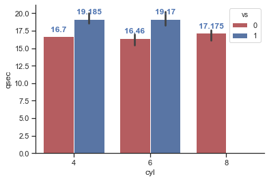

```python
from numpy import median
sns.set(style="ticks", color_codes=True)
b=sns.barplot('cyl','qsec',estimator=median,data=data,hue='vs',palette={0:'r',1:'b'})
sns.despine()
for bar in b.patches:
    b.annotate("{:,}".format(bar.get_height()),
              (bar.get_x()+bar.get_width()/2.,bar.get_height()),
               ha='center',va='center',xytext=
                           (0,10),textcoords='offset points',
                            color='b', weight='bold')
```

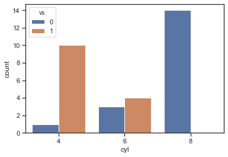

```python
sns.countplot('cyl',data=data,hue='vs')
```

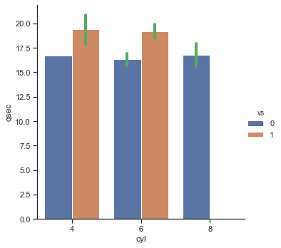

```python
sns.catplot('cyl','qsec',data=data,hue='vs',ci='sd',errcolor='g',errwidth=4,kind='bar')
```

## 提琴图violinplot

提琴图的宽度代表了数据的密集程度，同时还有分位线。

`split=True` 仅在hue变量为二进制时适用，并指定提琴的每一侧应填充不同的颜色，代表的值hue变量。

`inner=None`指定除了基于hue的颜色映射外，不在提琴的任何一侧绘制任何内容。

可以在该图上覆盖集群图等

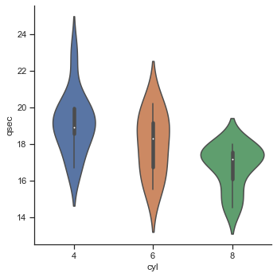

```python
sns.catplot('cyl','qsec',data=data,kind='violin')
```

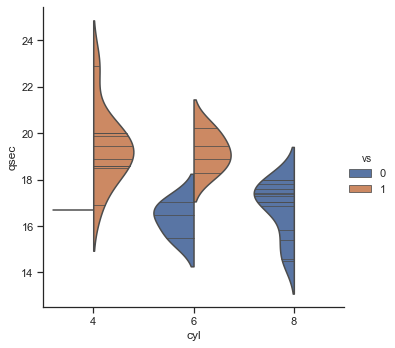

```python
sns.catplot('cyl','qsec',data=data,kind='violin',hue='vs',split=True,inner="stick")
```

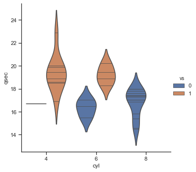

```python
sns.catplot('cyl','qsec',data=data,kind='violin',hue='vs',inner="stick")
```

## 点图

最后，point图将聚合度量描述为图形中的一个点，各个类别的所有此类点均用线连接。比较几个可比较的列。

ci，capsize，markers，dodge

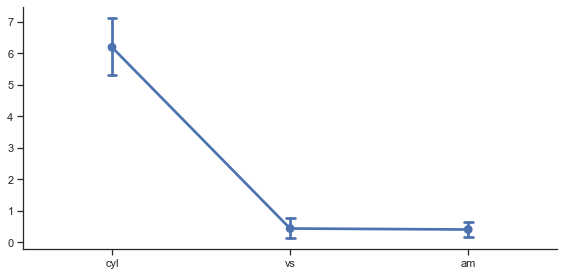

```python
sns.set(style="ticks", color_codes=True)
sns.catplot(data=data, kind='point', ci=99.99, capsize=0.05,
            height=4, aspect=2, order=['cyl','vs','am'])
```

# 分布图

分布图用于可视化数据的概率分布。 Seaborn 提供了三个函数：`distplot()`，`kdeplot()`和`rugplot()。`

distplot()只能绘制单变量的概率分布，而kdeplot是绘制单变量或双变量的概率分布

rugplot()是通常在distplot和kdeplot中设置参数rug=True绘制。

不支持data选项

## distplot

默认distplot绘制的是直方图,设置vertical=True可以绘制水平直方图

通过设置rug=True，kde=True，可以绘制低碳图和核密度曲线

通过设置hist_kws={}设置直方图的格式，

通过rug_kws={}设置rug格式

通过kde_kws={}设置kde格式

这三个可以在里面设置label参数，会在图形中自动生成图例

通过fit参数，添加拟合曲线，从scipy包导入一些分布曲线，一般此时设置为kde为False，不过也可以保留以做比较。

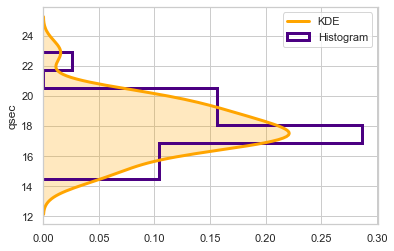

```python
import matplotlib.pyplot as plt
import seaborn as sns
from scipy.stats import norm, pareto, gamma
sns.set(style="whitegrid", color_codes=True)
sns.distplot(data.qsec, vertical=True,
             hist_kws={"histtype": "step", "linewidth": 3, "alpha":
             1, "color": "indigo", "label": "Histogram"},
             kde_kws={"shade": True, "color": "orange", "lw": 3,
                      "label": "KDE"})
```

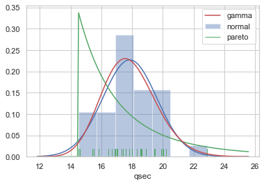

```python
ax = sns.distplot(data.qsec, fit=norm, kde=False,
                  rug=True, color='b',
                  fit_kws={"color": "b"}, label='normal')
sns.distplot(data.qsec, hist=False, fit=pareto,
             kde=False, rug=True, color='g', label='pareto',
             fit_kws={"color": "g"}, ax=ax)
sns.distplot(data.qsec, hist=False, fit=gamma,
             kde=False, color='r', label='gamma',
             fit_kws={"color": "r"}, ax=ax)
ax.legend()
```

[output not shown]

## kdeplot()

KDE 是一种将分布函数拟合到给定数据集的非参数方法。 因此，对于给定的单变量（单变量）或双变量（两个变量）数据，kdeplot()拟合并绘制 KDE 分布曲线。

`kerner`:kernel='epa'指定要用于适合 KDE 的内核方法（Epanechnikov）。 其他可用选项包括gau（高斯/正态），cos（余弦），biw（双权），triw（三权）和tri（三角形）。

cmap='Reds'指定要使用的颜色表。

cbar=True指定绘制颜色条

n_levels=25指定要绘制的轮廓数量。

shade=True填充轮廓内的区域。

shade_lowest=False仅适用于shade=True，仅适用于二元 KDE 图。 它迫使它不填充最外轮廓，该轮廓覆盖轮廓外轴域的整个区域。 如果我们不将其设置为false，则可能会看到整个轴域的区域都填充了最外面轮廓的颜色。

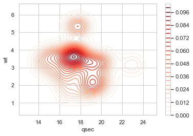

```python
sns.kdeplot(data.qsec,data.wt,kernel='epa', n_levels=25, cmap='Reds', cbar=True)
```

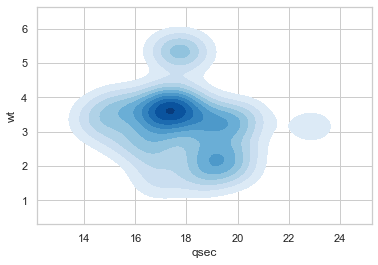

```python
sns.kdeplot(data.qsec,data.wt, kernel='cos',
            shade=True, shade_lowest=False, cmap='Blues')
```

# 回归图

回归图有助于将二维数据拟合为线性或多项式曲线。 这有助于可视化两个变量之间的关系，以了解它与 n 的线性或多项式拟合的紧密程度。

Seaborn 为此提供了三个函数：regplot()，residplot()和lmplot()。regplot()和lmplot()都具有将二维数据拟合为 n 的线性或多项式的相同目的，但是regplot()是轴域级函数，而lmplot()是图形级函数，使它能够使用row和col语义变量在单个图形中绘制多个回归图。residplot()帮助拟合曲线并绘制残差以了解拟合的质量。

## regplot

```
truncate=True指定仅在可用数据点之前拟合曲线。 默认设置是将其扩展到轴域的两端。
ci=99指定在线性曲线的周围绘制 99% 的置信区间。
scatter_kws={'color': 'r'}是散点图关键字字典，具有要使用的属性。 用红色绘制点。
line_kws={'color': 'red'}指定回归线的颜色。
order=2指定拟合二阶多项式。
logistic=True指定拟合逻辑回归曲线。要求是目标变量已经被二分化，数字化
n_boot=750指定用于估计和置信区间的重采样次数。
y_jitter=.03指定要添加的偏差量，以使点不会重叠太多。 这仅影响可视化，并在拟合曲线之后和绘制之前添加。
```

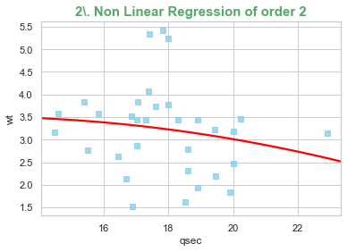

```python
g2 = sns.regplot(x='qsec', y='wt', data=data,
                 order=2, ci=None,
                 marker='s', scatter_kws={'color': 'skyblue'},
                 line_kws={'color': 'red'});
plt.title('2\. Non Linear Regression of order 2', size=15, color='g',
           weight='bold')
```

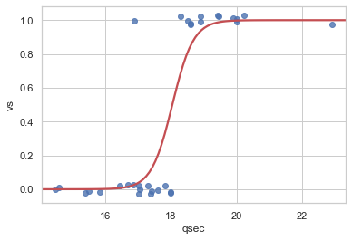

```python
 sns.regplot(x='qsec', y='vs', data=data,logistic=True,
                 n_boot=750, y_jitter=.03,
                 line_kws={'color': 'r'})
plt.show()
```

## residplot

与regplot相似，但是会有残差。

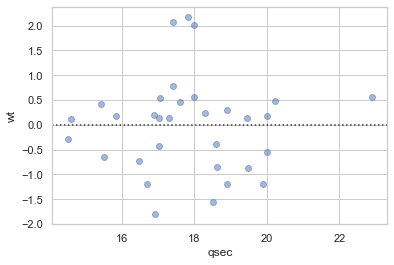

```python
g3 = sns.residplot(x='qsec', y='wt', order=2,
                   data=data, scatter_kws={'color': 'b',
                   'alpha': 0.5})
```

## lmplot

可以使用hue，col等变量

```
logx=True指定拟合形式为y = log(x)的曲线。
robust=True指定要减轻离群值对曲线拟合数据的影响。
lowess=True指定拟合非参数回归模型
```

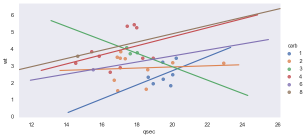

```python
import matplotlib.pyplot as plt
import seaborn as sns
sns.set(style="dark", color_codes=True)
sns.lmplot(x='qsec', y='wt', hue='carb',
                data=data, height=4, aspect=2, ci=None)
```

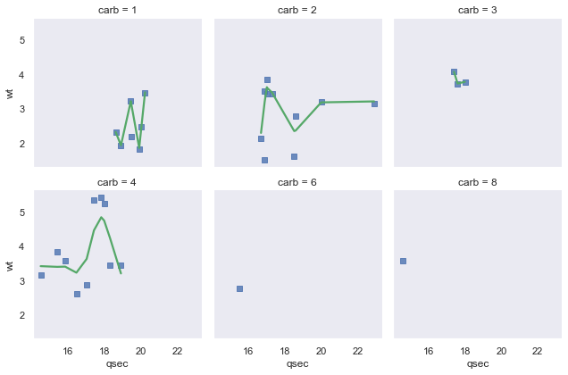

```python
sns.lmplot(x='qsec', y='wt',
                data=data,lowess=True, markers='s',
                col='carb',  col_wrap=3,
                height=3, line_kws={'color': 'g'})
```